# CPC Experiment analysis

## Experimental Design

Communities were assembled from a five-species ciliate pool and designed to span three richness levels: two, three, and four species. For each richness level, all possible species combinations were evaluated using their predicted community performance variability $CV(CP)$, which were calculated from single-species thermal performance curves measured in a previous experiment. For each temperature regime and richness level, we selected three community compositions that represented a gradient in expected CPC variability: the composition with the lowest CV of community performance, the composition with the highest CV, and the composition closest to the mean CV. This produced a factorial design with three richness levels, three selected compositions per richness level, four temperature time series, and three replicate microcosms per treatment combination ($n = 108$). We sampled 27 times over the span of 37 days, resulting in 2916 samples.

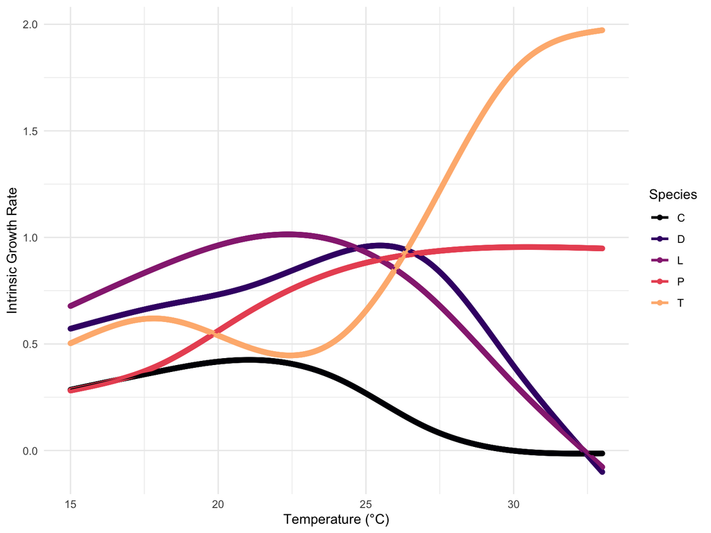

Figure 1: Thermal performance curves

### Temperature Regime

The temperature treatments consisted of four fluctuating time series. Temperature values were drawn from a normal distribution with reddened noise ($\gamma$ = 0.8), a mean of 22.5°C and a standard deviation of 3.5°C (Figure 2). Before the fluctuating treatments began, communities were kept at a constant 22.5°C for four days; this initial stable period was later removed before analysis. The four generated temperature time series were then used both as experimental temperature regimes and to calculate actual community performance based on the temperatures experienced by each community.

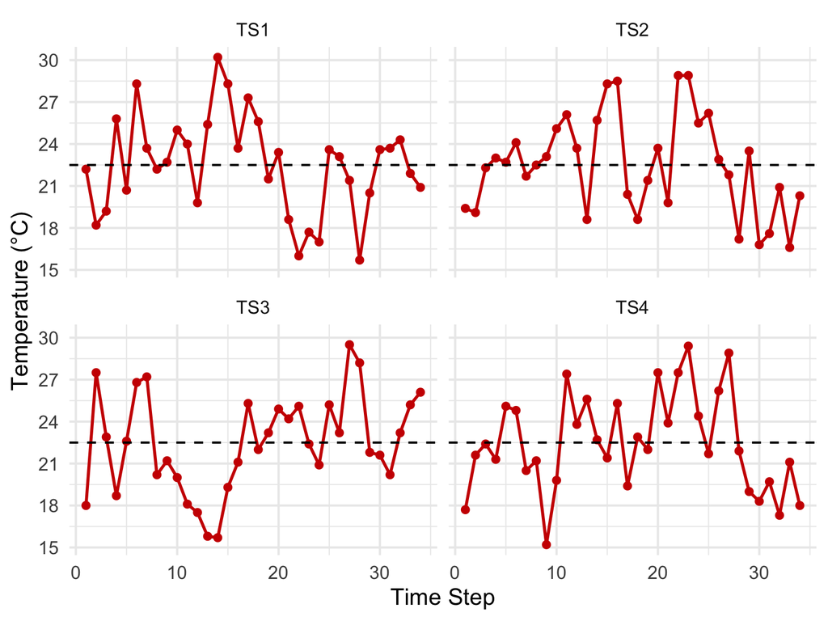

Figure 2: Temperature time series

## Analysis

To quantify temporal variability in community biomass, we first removed the initial stable period (first two sampling days), leaving us with 2700 samples of which we excluded 3 due to sampling errors. We then detrended the species-level time series before calculating community variability. For each species within each community composition and across temperature time series, we fitted a smooth generalized additive model (GAM) describing the average change in density or biomass over experimental day (Figure 3). This smooth trend was fitted using all replicate observations available for that species-composition combination. The fitted trend represents the shared temporal trajectory expected from gradual directional change over the experiment.

We tested whether this observed community variability could be predicted from four stand-alone predictors: variability in actual community performance ($CV(CP_{\text{actual}})$), variability in null community performance ($CV(CP_{\text{null}})$), the absolute distance between mean thermal optimum and mean environmental temperature ($|\bar{T}_{opt} - \bar{T}|$), and variation in thermal optima among species ($sd(T_{opt})$). Each predictor was analysed in a separate linear model with detrended community biomass variability as the response variable. Log-transformations were applied to improve model diagnostics. For these models, we report the coefficient estimate (β), *t* value, *p* value, and $R^2$. In addition, we tested whether species richness alone predicted community variability, and used the ANOVA output from the full model including observed community performance and richness to ask whether richness explained additional variation after accounting for observed community performance.

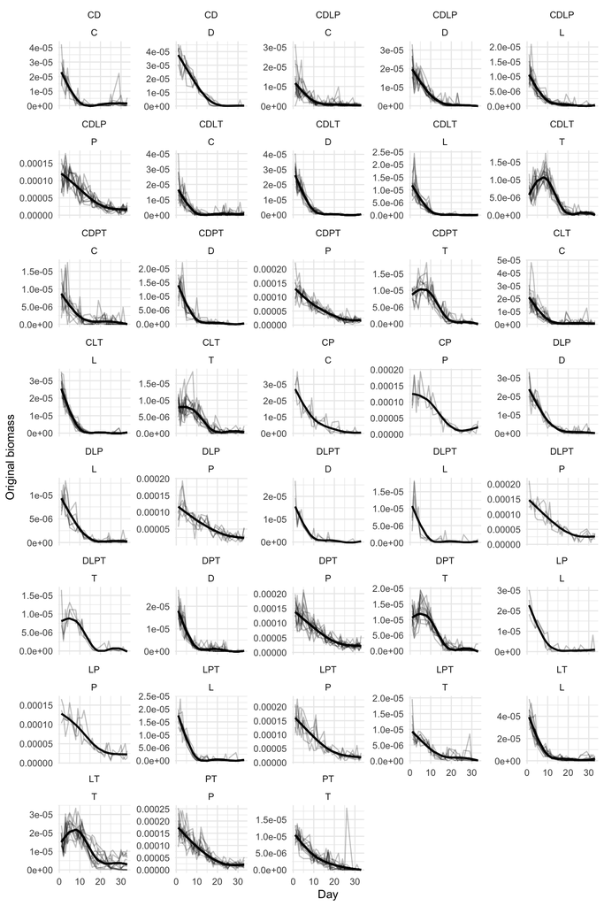

Figure 3: Fitted biomass trend overlayed over observed time series

## Main Result

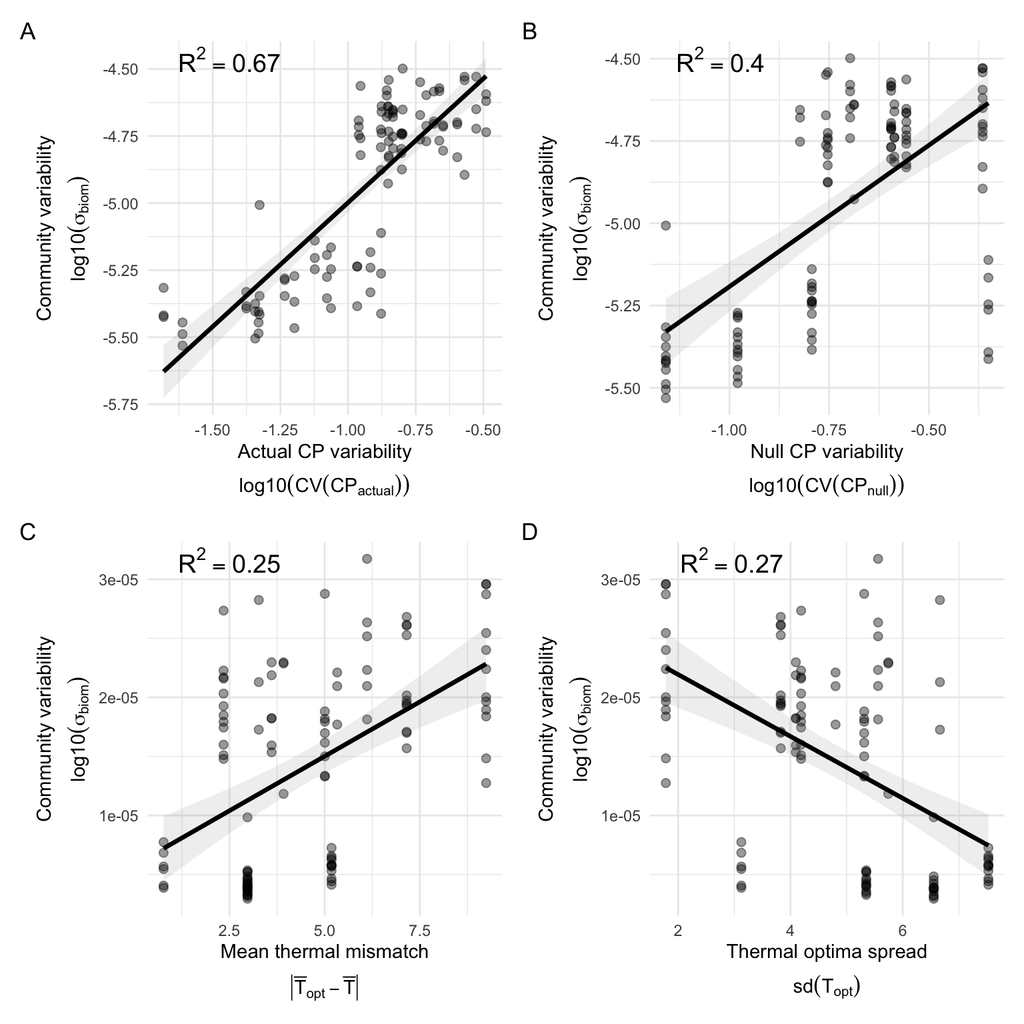

Figure 4: Effect of Actual/Null Variability of Community Performance and of trait summaries

## Full Model Results

The full model included $CV(CP_{\text{actual}})$, species richness, temperature time series, and the interaction between $CV(CP_{\text{actual}})$ and richness. Together these terms explained most of the variation in detrended community biomass variability (adjusted $R^2$ = 0.83; overall $F$(8, 99) = 67.11, *p* = < 0.001). $CV(CP_{\text{actual}})$ remained the strongest component of the model ($F$(1, 99) = 426.97, *p* = < 0.001), and the relationship between $CV(CP_{\text{actual}})$ and biomass variability differed among richness levels ($F$(2, 99) = 12.03, *p* = < 0.001).

Estimated slopes remained positive at all richness levels (richness 2: β = 1.26; richness 3: β = 0.92; richness 4: β = 1.49), but the slope was shallower for three-species communities than for two-species communities, while four-species communities showed a steeper but less clearly distinct slope (richness 3 vs. richness 2: β = -3.42e-01, *p* = 0.005; richness 4 vs. richness 2: β = 2.31e-01, *p* = 0.126). Temperature time series also contributed to the full model ($F$(3, 99) = 6.42, *p* = < 0.001). The plots below (Figure 5) show these two views of the same $CV(CP_{\text{actual}})$ effect: grouped by richness on the left and by temperature time series on the right.

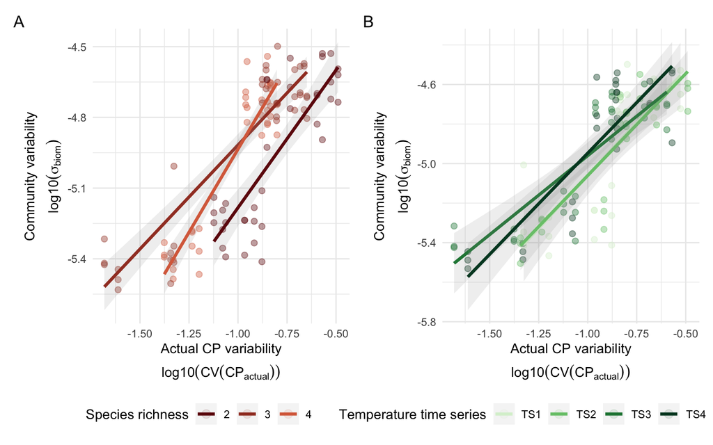

Figure 5: Effect of richness and temperature time series

## Mechanistic breakdown

For species biomass time series $b_i(t)$, community biomass is $b_{\text{c}}(t)=\sum_i b_i(t)$. The coefficient of variation of community biomass can be decomposed into biomass synchrony ($\phi_{\text{biom}}$) and weighted mean population variability:
$$CV_{\text{biom}} = \frac{\sigma(b_{\text{c}}(t))}{\overline{b_{\text{c}}(t)}} = \sqrt{\phi_{\text{biom}}}\sum_i w_iCV(b_i),$$
where
$$\phi_{\text{biom}} = \frac{\sigma^2\left(\sum_i b_i(t)\right)}{\left(\sum_i \sigma(b_i(t))\right)^2}
\quad\text{and}\quad
w_i = \frac{\overline{b_i(t)}}{\overline{b_{\text{c}}(t)}}.$$
Because we detrended the biomass time series and analyze the standard deviation of detrended community biomass rather than raw biomass $CV$, the empirical relationship used here looks slightly different. The response is $\sigma_{\text{biom}}$, which can be written as
$$\sigma_{\text{biom}} = \sqrt{\phi_{\text{biom}}}\sum_i \sigma(b_i(t)) = \sqrt{\phi_{\text{biom}}}\,S\,\bar{\sigma}_{\text{biom}},$$
where $S$ is species richness and $\bar{\sigma}_{\text{biom}}$ is mean population biomass variability. Analogously, for species performance $r_i(t)$, community performance is $CP_{\text{actual}}(t)=\sum_i r_i(t)$ and
$$CV(CP_{\text{actual}}) = \frac{\sigma(CP_{\text{actual}}(t))}{\overline{CP_{\text{actual}}(t)}} = \sqrt{\phi_{\text{perf}}}\sum_i w_iCV(r_i),$$
where $\phi_{\text{perf}} = \sigma^2(CP_{\text{actual}}(t))/(\sum_i \sigma(r_i(t)))^2$ and $w_i=\overline{r_i(t)}/\overline{CP_{\text{actual}}(t)}$ (Figure 6, panel A & B). Thus, $CV(CP_{\text{actual}})$ integrates both performance synchrony and weighted mean species performance variability.

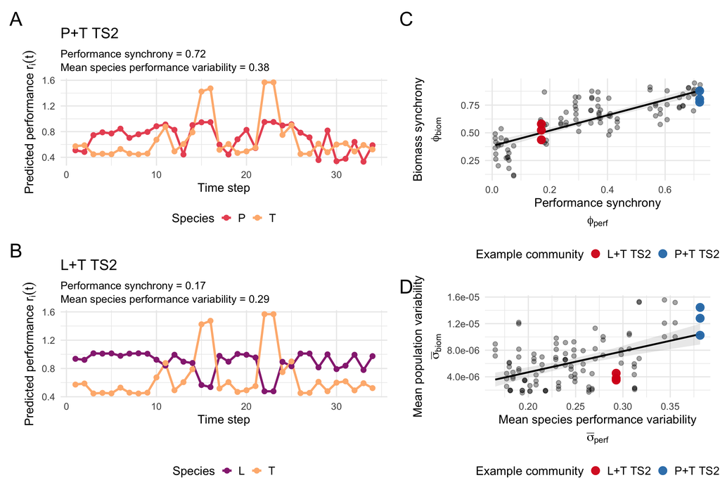

Figure 6: Mechanistic breakdown of performance variability. The left panels show predicted species performance through TS2 for two example communities, P+T and L+T. The right panels show how performance synchrony and mean species performance variability relate to biomass synchrony and mean population variability across all communities; larger highlighted points mark the two example communities.

Across all communities, synchrony of performance curves strongly predicted synchrony of biomass fluctuations (Figure 6, panel C): communities with more synchronous performance also showed more synchronous biomass dynamics ($R^2=$ 0.65; β = 6.93e-01, *p* = < 0.001). Mean species performance variability was positively related to mean population variability (Figure 6, panel D) ($R^2=$ 0.24; β = 3.16e-05, *p* = < 0.001).

We tested whether $CV(CP_{\text{actual}})$ affects community variability through both of those pathways using structural equation modelling (SEM), while accounting for species richness. Furthermore, we tested whether species richness would have a stabilising effect on the community through intrinsic performance ($CV(CP_{\text{actual}})$). For the SEM, biomass synchrony was defined as $\phi_{\text{biom}}=\sigma^2(\sum_i b_i(t))/(\sum_i \sigma(b_i(t)))^2$, mean population variability as $\bar{\sigma}_{\text{biom}}=S^{-1}\sum_i \sigma(b_i(t))$, and community variability as $\sigma_{\text{biom}}=\sigma(\sum_i b_i(t))$. All variables were standardized; biomass synchrony, biomass variability terms, and richness were log-transformed so that the interactive effect between synchrony and mean population variability changed to additive. The fitted relationships were $CV(CP_{\text{actual}}) \sim \log_{10}(S)$, $\log_{10}(\phi_{\text{biom}}) \sim CV(CP_{\text{actual}})$, $\log_{10}(\bar{\sigma}_{\text{biom}}) \sim CV(CP_{\text{actual}})$, and $\log_{10}(\sigma_{\text{biom}}) \sim \log_{10}(\phi_{\text{biom}}) + \log_{10}(\bar{\sigma}_{\text{biom}}) + \log_{10}(S)$, with residual covariance between $\log_{10}(\phi_{\text{biom}})$ and $\log_{10}(\bar{\sigma}_{\text{biom}})$. We hypothesized that $CV(CP_{\text{actual}})$ would be positively related to both biomass synchrony and mean population variability, which in turn should increase community biomass variability.

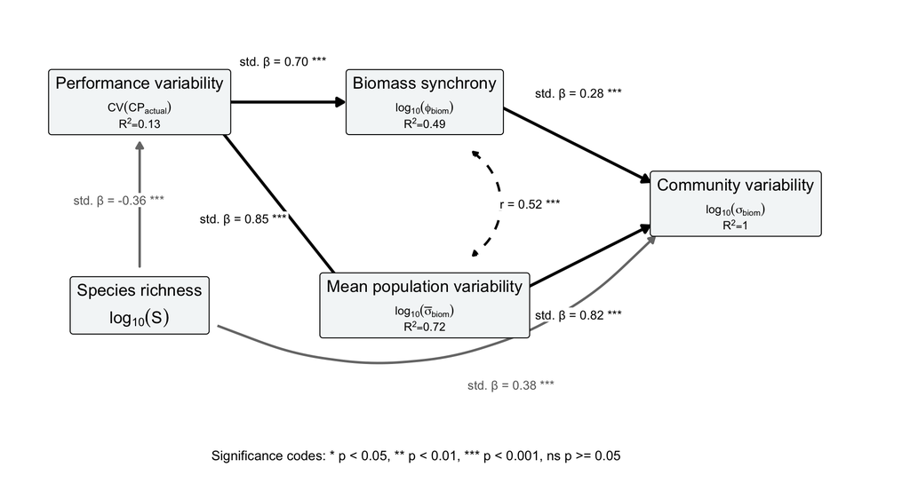

Figure 7: Structural equation model for the mechanistic pathways from performance variability to community biomass variability. Path labels show standardized effects and significance codes; node labels show explained variance (R²). Grey arrows show richness paths, and the dashed double-headed arrow shows the residual correlation between biomass synchrony and mean population variability.

THe SEM supported both proposed performance pathways after accounting for richness (Figure 7). Richness was related to $CV(CP_{\text{actual}})$ (β = -0.36, z = -3.93, *p* = < 0.001; $R^2$ = 0.13), and $CV(CP_{\text{actual}})$ was associated with both $\log_{10}$ biomass synchrony (β = 0.70, z = 9.39, *p* = < 0.001; $R^2$ = 0.49) and $\log_{10}$ mean population biomass variability (β = 0.85, z = 16.55, *p* = < 0.001; $R^2$ = 0.72). Downstream, both biomass components were related to $\log_{10}$ community biomass variability, although the mean-population-variability pathway was stronger (β = 0.82, z = 308.90, *p* = < 0.001) than the synchrony pathway (β = 0.28, z = 112.53, *p* = < 0.001). Richness also had a direct path to community variability (β = 0.38, z = 236.35, *p* = < 0.001). Together, the model explained most variation in $\log_{10}(\sigma_{\text{biom}})$ ($R^2$ = 1.00), and SEM1 showed adequate overall fit ($\chi^2$(3) = 5.71, *p* = 0.127; CFI = 0.998, RMSEA = 0.091, SRMR = 0.031).

## Effect of Species Richness

Species richness showed no consistent relationship with community variability (Figure 8). In the reduced model including only richness, neither richness contrast differed clearly from the two-species baseline (richness 3 vs. richness 2: β = 5.09e-02, *p* = 0.511; richness 4 vs. richness 2: β = 2.17e-02, *p* = 0.779). In the full model including $CV(CPC_{\text{actual}})$, richness, and temperature series, the main effect of richness was not significant ($F$(2, 99) = 1.32, *p* = 0.271). This suggests that richness did not explain additional variation in community variability once observed CPC and temperature series were accounted for. However, richness did interact with $CV(CPC_{\text{actual}})$ ($F$(2,99) = 12.03, *p* = < 0.001) (see Figure 5).

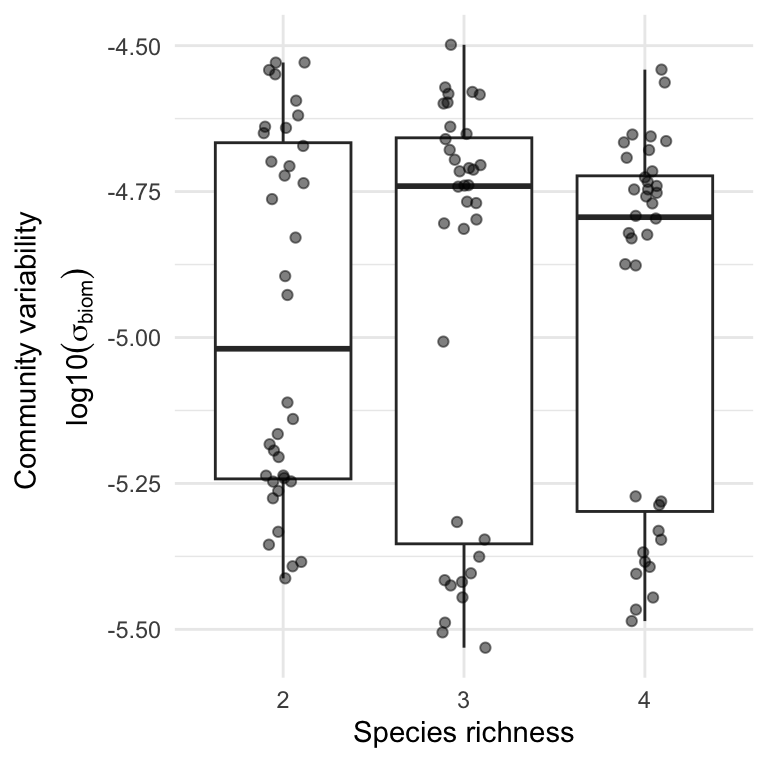

Figure 8: Effect of species richness